# Mental Health Outcomes in Gamers

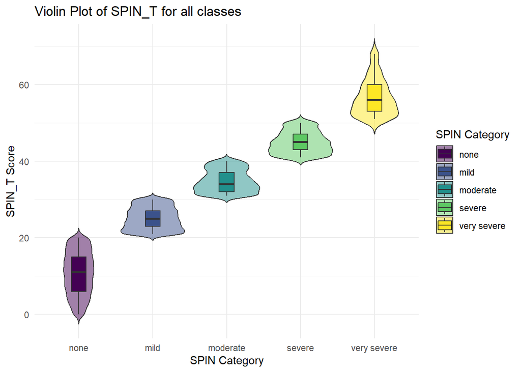

```r
# Violin plot to visualize the distribution with y-axis scaled from 0 to 9
ggplot(minimal_mild, aes(x = SPIN_ord, y = SPIN_T, fill = SPIN_ord)) +
  geom_violin(trim = FALSE, alpha = 0.5) +
  geom_boxplot(width = 0.2, position = position_dodge(0.9)) +
  labs(title = "Violin Plot of SPIN_T for all classes",
              x = "SPIN Category", y = "SPIN_T Score", fill = "SPIN Category") +
  theme_minimal()
```

There was difficulty in differentiating the mild and moderate classes, so they will be consolidated to mild-moderate.

```r
# Consolidate 'mild' and 'moderate' into 'mild-moderate'
df_undersampled_spin$SPIN_ord <- factor(
  ifelse(df_undersampled_spin$SPIN_ord %in% c("mild", "moderate"),
         "mild-moderate",
         as.character(df_undersampled_spin$SPIN_ord)),  # Retain other classes
  levels = c("none", "mild-moderate", "severe", "very severe")  # Define desired order
)

# Verify structure
#str(df_undersampled_spin)

# Check the levels
#levels(df_undersampled_spin$SPIN_ord)

# Check the distribution of the consolidated class
#table(df_undersampled_spin$SPIN_ord)

# Visualize the feature distribution by the new consolidated class
#ggplot(df_undersampled_spin, aes(x = Hours, fill = SPIN_ord)) +
 # geom_density(alpha = 0.5) +
  #labs(title = "Feature Distribution by Class (Consolidated)", x = "Hours", y = "Density")
```

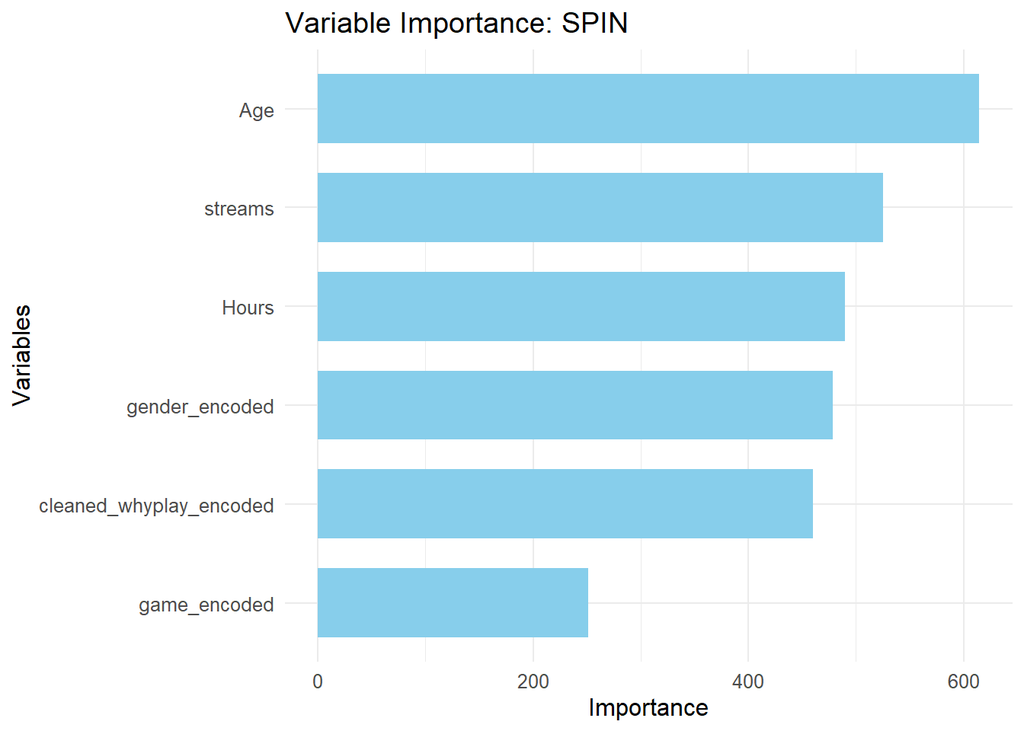

```r
df_undersampled_spin$SPIN_ord <- as.factor(df_undersampled_spin$SPIN_ord)


#class_weights <- c("none" = 3, "mild" = 3, "moderate" = 2, "severe" = 1, "very severe" = 1)
model_bal_spin <- randomForest(SPIN_ord ~ cleaned_whyplay_encoded + Hours + streams + game_encoded + gender_encoded + Age ,
                             data = df_undersampled_spin,
                            ntree = 3000,
                           mtry = 4,
                        nodesize = 3,
                         importance = TRUE
                       )



#cat("Accuracy -- bal: ", mean(predict(model_bal_spin) == df_undersampled_spin$SPIN_ord), "\n")

#print(model_bal_spin)

#importance(model_bal2)
#varImpPlot(model_bal_spin)


# Extract MeanDecreaseAccuracy from the variable importance
var_imp <- importance(model_bal_spin)
var_imp_df <- data.frame(
  Variable = rownames(var_imp),
  Importance = var_imp[, "MeanDecreaseAccuracy"]
)

# Plot MeanDecreaseAccuracy using ggplot2
ggplot(var_imp_df, aes(x = reorder(Variable, Importance), y = Importance)) +
  geom_bar(stat = "identity", fill = "skyblue", width = 0.7) +
  coord_flip() + # Flip axes for better readability
  theme_minimal() +
  labs(title = "Variable Importance: SPIN",
       x = "Variables",
       y = "Importance") +
  theme(text = element_text(size = 12))
```

```r
# Confusion Matrix data for the second model
conf_matrix <- matrix(c(
  1616, 1699, 149, 36,  # none
  1462, 3263, 310, 134, # mild-moderate
  264, 534, 1215, 60,   # severe
  107, 217, 38, 1118    # very severe
), nrow = 4, byrow = TRUE)

# Assign class names
colnames(conf_matrix) <- rownames(conf_matrix) <- c("none", "mild-moderate", "severe", "very severe")

# Calculate metrics
accuracy <- diag(conf_matrix) / rowSums(conf_matrix)  # Accuracy for each class
precision <- diag(conf_matrix) / colSums(conf_matrix) # Precision for each class
recall <- diag(conf_matrix) / rowSums(conf_matrix)    # Recall for each class
f1_score <- 2 * (precision * recall) / (precision + recall) # F1-Score for each class

# Overall accuracy (calculated from total confusion matrix)
overall_accuracy <- sum(diag(conf_matrix)) / sum(conf_matrix)

# Create a data frame with the metrics
metrics <- data.frame(
  Class = c("none", "mild-moderate", "severe", "very severe"),
  Accuracy = round(accuracy, 3),
  Precision = round(precision, 3),
  Recall = round(recall, 3),
  F1_Score = round(f1_score, 3),
  Overall_Accuracy = round(rep(overall_accuracy, 4), 3)  # Replicate overall accuracy for each class row
)

# Format the table using kable
metrics_table <- metrics %>%
  kable(format = "html", digits = 3, align = "lcccccc") %>%
  kable_styling(full_width = F, position = "center") %>%
  column_spec(1, bold = TRUE) %>%
  add_header_above(c(" " = 1, "Metrics" = 5, " " = 1)) %>%  # Adjust header grouping
  row_spec(0, bold = TRUE, color = "white", background = "#4CAF50") %>%
  row_spec(1:nrow(metrics), color = "black", background = "#f2f2f2") %>%
  footnote(
    general = "Table showing model evaluation metrics per class and overall accuracy.",
    general_title = "Note:"
  )

# Print the table
metrics_table
```

|  | Metrics Class | Metrics Accuracy | Metrics Precision | Metrics Recall | Metrics F1_Score | Overall_Accuracy |
| --- | --- | --- | --- | --- | --- | --- |
| none | none | 0.462 | 0.469 | 0.462 | 0.465 | 0.59 |
| mild-moderate | mild-moderate | 0.631 | 0.571 | 0.631 | 0.600 | 0.59 |
| severe | severe | 0.586 | 0.710 | 0.586 | 0.642 | 0.59 |
| very severe | very severe | 0.755 | 0.829 | 0.755 | 0.791 | 0.59 |

Note:  
Table showing model evaluation metrics per class and overall accuracy.

Age being the most important variable for SPIN suggests that the effects of video games might depend of demographic facts such as the age of the player.

# Key Findings

Logistic:

The analysis aimed to predict whether an individual’s weekly screen time exceeds 15 hours using logistic regression. It also aimed to identify factors influencing whether individuals exceed 15 hours of weekly screen time (gaming and streaming). Key predictors include age, work status, gender, gaming platform, and motivations for playing. Initial findings revealed that the model has a high overall accuracy (84%) at the default 0.5 cut-off, but this comes at the cost of extremely low specificity (0.0066), meaning it struggles to correctly identify those below the 15-hour threshold. Adjusting the cut-off to 0.839 improves balance, with precision increasing to 0.891 and recall at 0.603, making the model more practical for predicting both high and low screen-time users. The model’s McFadden’s Pseudo-R² (0.0383) and AUC (0.638) suggest it has limited explanatory power and fair discrimination ability. While the optimal cut-off enhances performance, the model could still be improved with additional features or alternative approaches.

Based on the cited research, excessive screen time (beyond 15 hours weekly) correlates with negative mental health outcomes, including a higher likelihood of suicide-related outcomes. This model, while limited in explaining variability, provides a practical tool for identifying individuals at risk of excessive screen time. With further refinement, it could serve as a useful framework for targeting interventions aimed at promoting healthier screen-time habits.

Trees:

GAD is predictable using the available features. The power of the “whyplay” variable should warrant more reseach, given its significant influence on classifying levels of anxiety.

SWL and SPIN require more gaming habit/demographic features and greater engineering investment.It is possible that evaluation metrics can improve given more sensitive models. For now, it seems apparent that stream/hours effect satisfaction with life and that a respondents age greatly impacts their level of social phobia.

# References

Cam Adair. (2016). Screen Time Guidelines for All Ages - Game Quitters. In *https://gamequitters.com/*. https://gamequitters.com/screen-time-guidelines/

Mary Fristad. (2019). Do adults need screen-time limits as much as young people? In *The Ohio State University Wexner Medical Center*. https://wexnermedical.osu.edu/blog/do-adults-need-screen-time-limits-as-much-as-young-people

NIH. (2013). *Reduce Screen Time, NHLBI, NIH*. https://www.nhlbi.nih.gov/health/educational/wecan/reduce-screen-time/index.htm